# Storytelling

Author

Zuoming Hu

## **A Century of Progress in the Olympics**

The story of the modern Olympics begins with gradual growth. From the early 1900s to 1980, athlete participation fluctuated due to global events like wars and economic challenges. Post-1980, however, a rapid increase in participation marked a new era, driven by globalization and enhanced sports funding. By 2000, participation reached a plateau, signaling maturity in global representation.

The Olympics reflect society’s evolving values, and gender equity is no exception. Before 1980, females’ participation lagged significantly. A transformation began in the 1980s, and by 2000, gender ratios approached parity. This shift highlights decades of advocacy and reforms, underscoring the Olympics as a platform for progress in equity and representation.

Medal counts tell the story of competition and dominance. The United States leads by a wide margin, showcasing its sporting infrastructure and investment. Germany follows, with Russia and China contributing significantly. These figures illustrate regional disparities and highlight the global nature of Olympic achievement.

This six-part journey through the Olympics showcases its transformation from a modest event to a global celebration of inclusivity, excellence, and diversity. Each visual tells a unique chapter of progress, helping us understand how sports reflect broader societal trends.

- **Global Growth in Athlete Participation**

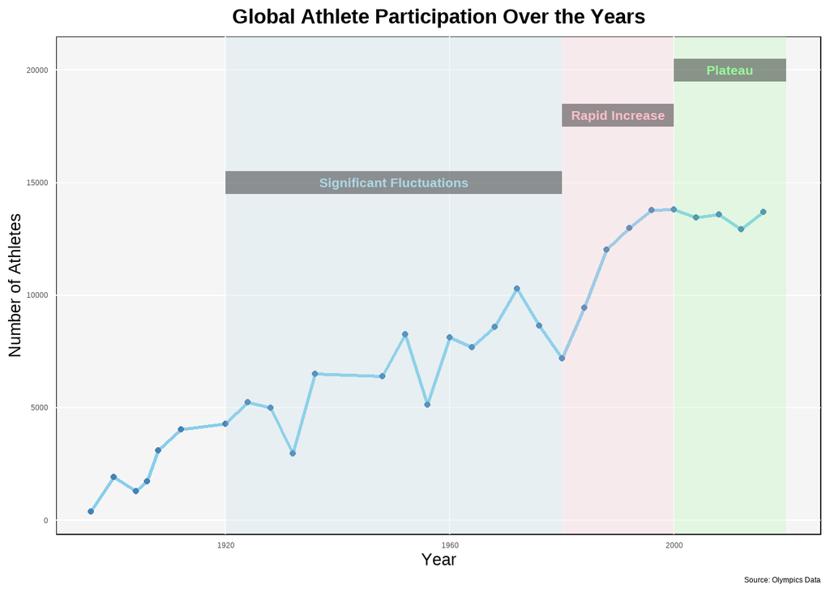

- **Advancing Gender Equity in Sports**

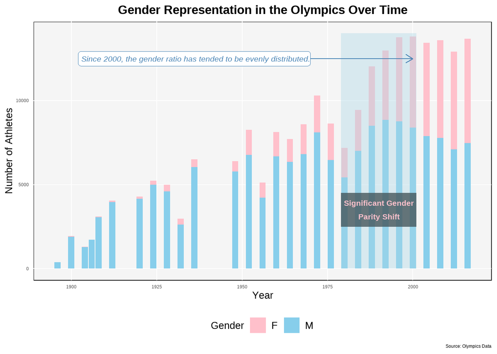

[figure not shown]

- **Comparing Age Density by Gender**

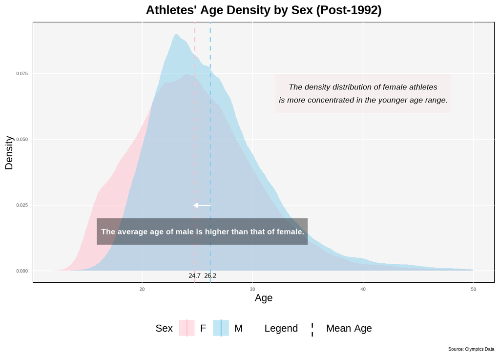

- **Sports that Shape the Olympics**

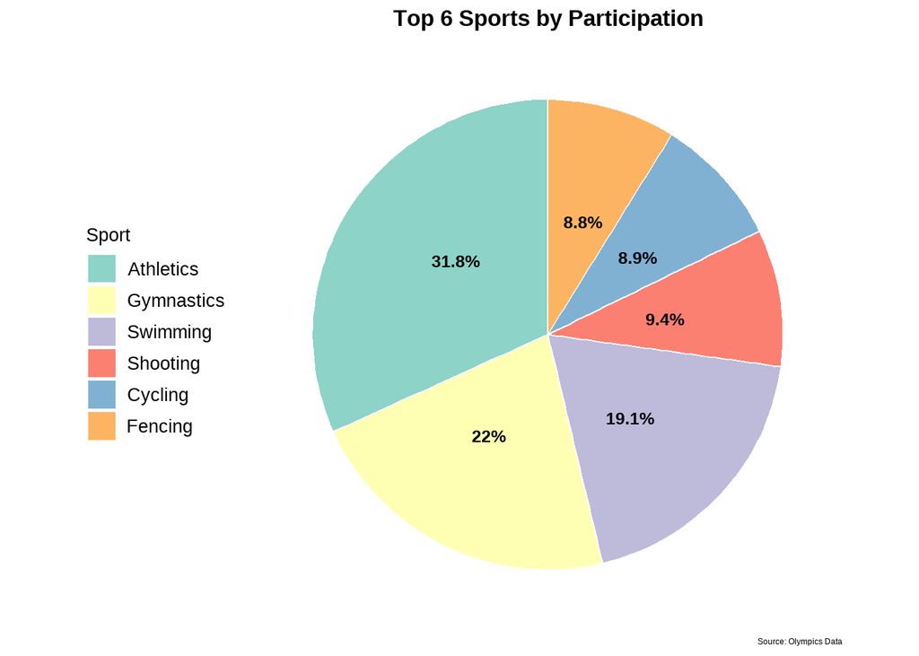

- **Medal Distribution Across Countries**

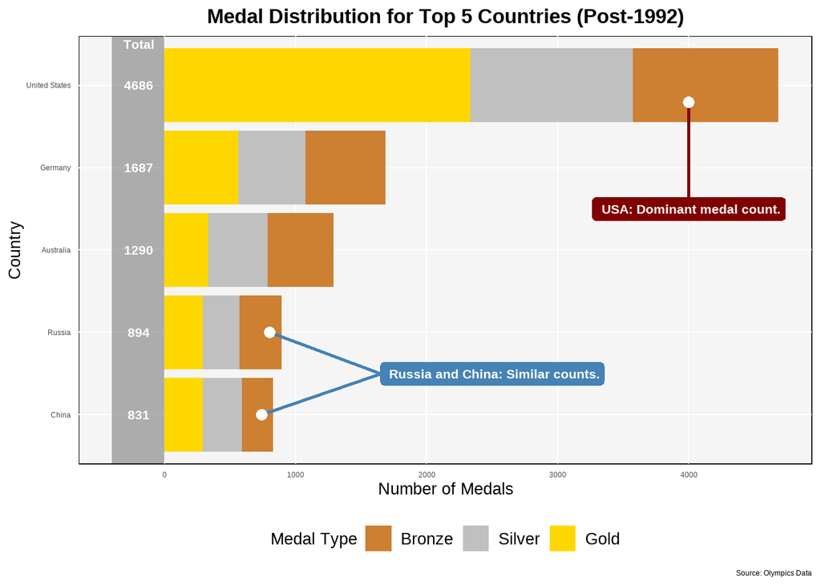

## Citations

- Cite R

  R Core Team (2023). *R: A Language and Environment for Statistical Computing*. R Foundation for Statistical Computing, Vienna, Austria. https://www.R-project.org
- Cite R Packages used

  Wickham H, Averick M, Bryan J, Chang W, McGowan LD, François R, Grolemund G, Hayes A, Henry L, Hester J, Kuhn M, Pedersen TL, Miller E, Bache SM, Müller K, Ooms J, Robinson D, Seidel DP, Spinu V, Takahashi K, Vaughan D, Wilke C, Woo K, Yutani H (2019). “Welcome to the tidyverse.” _Journal of Open Source Software_, *4*(43), 1686. doi:10.21105/joss.01686. https://doi.org/10.21105/joss.01686

  Harmon J, Hughes E (2024). _tidytuesdayR: Access the Weekly ‘TidyTuesday’ Project Dataset_. R package version 1.1.2. https://CRAN.R-project.org/package=tidytuesdayR

  Gilbey L (2022). *ggwaffle: Waffle Charts*. R package version 0.2.5, https://github.com/liamgilbey/ggwaffle.

  Pedersen T, Robinson D (2024). *gganimate: A Grammar of Animated Graphics*. R package version 1.0.9.9000, https://gganimate.com.

  Guangchuang Yu (2016). emojifont: Emoji and Font Awesome in Graphics. R package version 0.5.5, https://cran.r-project.org/web/packages/emojifont.
- Data set: Olympics Data